# incident_cases.r

acoutoal

Fri Feb 3 11:36:15 2017

Unfortunately, I am afraid that incident only cases cannot prevent Berkson bias. Say individuals have 3 independent genetic variants that confere risk for 3 independent diseases. Can we prevent berkson bias by looking only at incident cases? That is, by only using the disease that first occured can we control this bias? In this setting, two independent risk factors will become associated with each other by chance and a false positive association with a disease will arise. Genetic background of each indinvidual:

- N - number of individuals
- Phi1 - frequency of mutation 1
- Phi2 - frequency of mutation 2
- Phi3 - frequency of mutation 3

```r
N    = 2000
Phi1 = .1
Phi2 = .2
Phi3 = .3
G1 = rbinom(n = N,prob = Phi1, size = 1)
G2 = rbinom(n = N,prob = Phi2, size = 1)
G3 = rbinom(n = N,prob = Phi3, size = 1)
Genotype = cbind(G1,G2,G3)
```

Life time and simulation time quanta

```r
years_longevity = 1               # Assume in this world, individuals die at 10y
lifetime = 365 * years_longevity  # Using 24 time quanta for the simulation
```

Assume constant hazard rates, i.e. the probabilities of disease incidence in 24h is a constant, irrespective of age, etc:

- The probability of developing disease D1 given variant G1 is P1
- The probability of developing disease D2 given variant G1 is P2
- The probability of developing disease D3 given variant G1 is P3

Assume identical hazard rates for all diseases

```r
P1 = .3 / lifetime
P2 = .3 / lifetime
P3 = .3 / lifetime
```

Keep a record of who went to the hospital with what disease We assume that hospitalization rate is 100% and that hospitalization. That is, disease occurance = hospitalization. As berkson notes, if hospitalization is 100% bias will be smaller.

We assume that hospitalization will cure the disease, but the disease may occur again, e.g. flu, bronchitis, drug depency. This doesent matter for the results because we only care about the first disease the patient ever had. Altough to be precise the simulation is based on recurrent and remission disease episodes, the actual treatment of the simulation makes the resultidentical for acute and chronic diseases.

```r
hospital = matrix(data = NA,nrow =  N,ncol =  lifetime)
for (iday in 1:lifetime) {
  D1 = as.logical(rbinom(n = N,prob = P1, size = 1)*G1)
  D2 = as.logical(rbinom(n = N,prob = P2, size = 1)*G2)
  D3 = as.logical(rbinom(n = N,prob = P3, size = 1)*G3)
  state = as.data.frame(cbind(D1,D2,D3))

  hospital[,iday] = apply(X = state, MARGIN = 1, FUN = function(x) ifelse( sum(x) > 0, max(which(x)),0 ))
}
```

Hospitalizations per individual

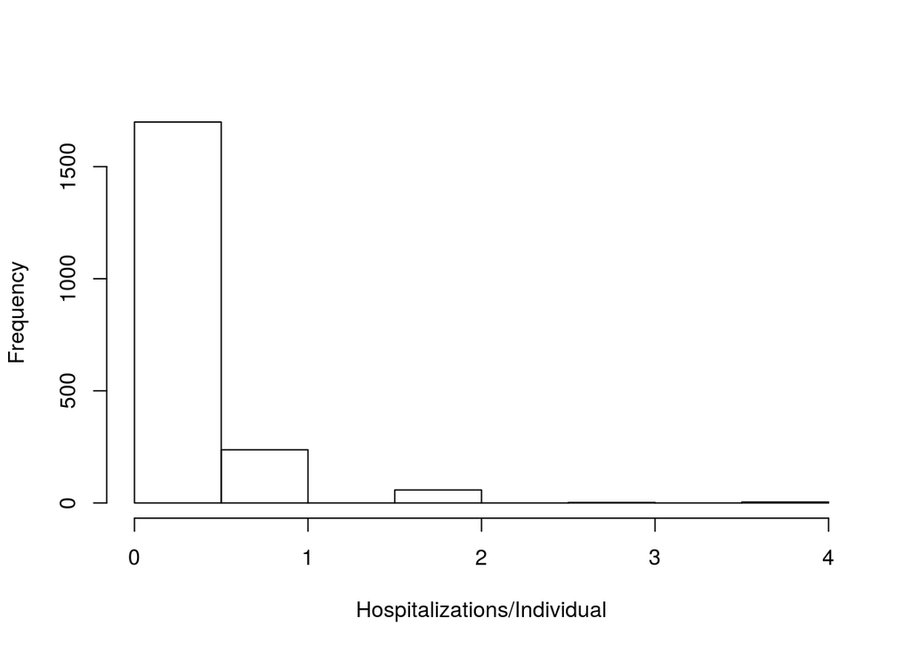

```r
hist(rowSums(hospital > 0,na.rm = T),xlab = "Hospitalizations/Individual",main = "")
```

Hospitalizations per day

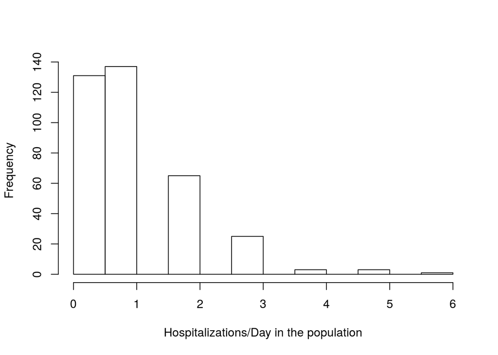

```r
hist(colSums(hospital > 0,na.rm = T),xlab = "Hospitalizations/Day in the population",main = "")
```

Produce a disease variable using incident cases i.e. select the disease that manifested first

```r
disease = matrix(data = 0,nrow = N,ncol = 1)
for (i in 1:N) {
  case       = hospital[i,]
  disease[i] = case[which.max(case > 0)] #Retrieve only first incident case
}
```

```r
sum(rowSums(Genotype) > 1)
```

```
## [1] 200
```

What I submit to you is that even if you just have one disease in your lifetime and then die, the individuals that have risk factors for multiple diseases are more frequent among incident cases and through this mechanism spurious associations between diseases and all independent risk factors are created. This is the actual mechanism by which berkson bias occur in the hospitalized population.It is not a matter of differential selection. Berkson paper uses constant selection for all diseases, but some individuals will have by change more than one disease.

Notice that even if the risk factors are completelly independent from each other, some individuals will still have multiple risk factors with probability P1 x P2 x P3.

Proportion of hospitalizations among carriers of multiple risk factors and single carriers

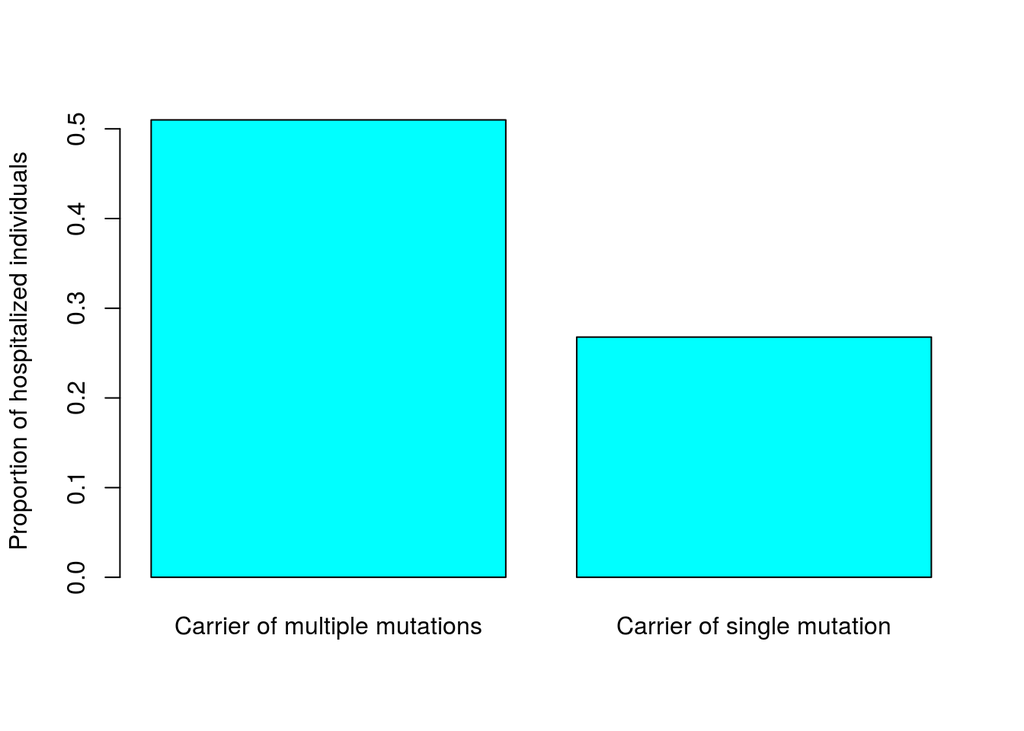

```r
barplot( c(mean(disease[rowSums(Genotype) > 1] > 0), mean(disease[rowSums(Genotype) == 1] > 0)),names.arg = c("Carrier of multiple mutations","Carrier of single mutation"),ylab="Proportion of hospitalized individuals", col= "cyan" )
```

Let’s analyse the whole population (with and without disease) and the hospitalized population.

```r
population_study = data.frame(disease = as.factor(disease), G1,G2,G3)
hospital_records = subset(population_study, disease != 0 )

results =
  rbind(

#Whole population analysis

cbind(
  rbind(
    coef(summary(glm( I(disease==1) ~ G1,  data =  population_study)))[2,c(1,4)],
    coef(summary(glm( I(disease==1) ~ G2,  data =  population_study)))[2,c(1,4)],
    coef(summary(glm( I(disease==1) ~ G3,  data =  population_study)))[2,c(1,4)]
  ),

  rbind(
    coef(summary(glm( I(disease==2) ~ G1, data =  population_study)))[2,c(1,4)],
    coef(summary(glm( I(disease==2) ~ G2, data =  population_study)))[2,c(1,4)],
    coef(summary(glm( I(disease==2) ~ G3, data =  population_study)))[2,c(1,4)]
  ),

  rbind(
    coef(summary(glm( I(disease==3) ~ G1, data =  population_study)))[2,c(1,4)],
    coef(summary(glm( I(disease==3) ~ G2, data =  population_study)))[2,c(1,4)],
    coef(summary(glm( I(disease==3) ~ G3, data =  population_study)))[2,c(1,4)]
  )
),

#Hospitalized population analysis

cbind(
  rbind(
    coef(summary(glm( I(disease==1) ~ G1, data =  hospital_records)))[2,c(1,4)],
    coef(summary(glm( I(disease==1) ~ G2, data =  hospital_records)))[2,c(1,4)],
    coef(summary(glm( I(disease==1) ~ G3, data =  hospital_records)))[2,c(1,4)]
  ),

  rbind(
    coef(summary(glm( I(disease==2) ~ G1, data =  hospital_records)))[2,c(1,4)],
    coef(summary(glm( I(disease==2) ~ G2, data =  hospital_records)))[2,c(1,4)],
    coef(summary(glm( I(disease==2) ~ G3, data =  hospital_records)))[2,c(1,4)]
  ),

  rbind(
    coef(summary(glm( I(disease==3) ~ G1, data =  hospital_records)))[2,c(1,4)],
    coef(summary(glm( I(disease==3) ~ G2, data =  hospital_records)))[2,c(1,4)],
    coef(summary(glm( I(disease==3) ~ G3, data =  hospital_records)))[2,c(1,4)]
  )
)
)

rownames(results) = c( paste0( rep("Population D=",3),1:3),
                       paste0( rep("Hospital D=",3),1:3) )

P_results = results[,seq(2,ncol(results),2)]
colnames(P_results) = paste0( rep("G",3),1:3 )
```

The population data only shows associations between disease and their respective risk factor. On the other hand, the risk factors are associated with all diseases in the hospitalized population

```r
print(P_results)
```

```
##                           G1            G2            G3
## Population D=1 4.793419e-120  2.431410e-01  8.255814e-01
## Population D=2  9.540382e-01 2.274748e-100  9.758064e-01
## Population D=3  4.000304e-01  1.351731e-01 8.979633e-106
## Hospital D=1    9.072565e-67  7.484156e-07  6.066984e-11
## Hospital D=2    5.776717e-05  1.022236e-55  1.873459e-20
## Hospital D=3    4.109703e-11  4.819561e-17  5.353325e-46
```